# Introduction to Nearest Neighbors Learning

Fokoue Ernest

This segment of the course provides a step by step introduction to some of the most foundational concepts of statistical machine learning, namely cross validation and the related stochastic hold out for comparing different statistical learning machines. The beautiful graphical tool known as Receiver Operating Characteristic Curve (ROC) is introduced. All these concepts are introduced using k Nearest Neighbors Learning Machines.

## Packages used in this segment

```r
  library(class)
  library(MASS)
  library(kernlab)
  library(mlbench)
  library(reshape2)
  library(ROCR)
  library(ggplot2)
```

## Dataset used in this segment

The famous Pima Indian Diabetes dataset is well known benchmark data used by my Machine Learning researchers in the context of classification learning. The input space in this case is only 7-dimensional and the classification is binary, but the underlying classification turns out to be rather challenging

```r
  data(PimaIndiansDiabetes)        # load the data
  xy <- PimaIndiansDiabetes        # Store data in xy frame
  help(PimaIndiansDiabetes)        # learn stuff about this dataset
  xy <- Pima.tr
```

Let’s have a look at the first six and the last six observations

```r
head(xy)
```

|  | npreg | glu | bp | skin | bmi | ped | age | type |
| --- | --- | --- | --- | --- | --- | --- | --- | --- |
| 1 | 5 | 86 | 68 | 28 | 30.2 | 0.364 | 24 | No |
| 2 | 7 | 195 | 70 | 33 | 25.1 | 0.163 | 55 | Yes |
| 3 | 5 | 77 | 82 | 41 | 35.8 | 0.156 | 35 | No |
| 4 | 0 | 165 | 76 | 43 | 47.9 | 0.259 | 26 | No |
| 5 | 0 | 107 | 60 | 25 | 26.4 | 0.133 | 23 | No |
| 6 | 5 | 97 | 76 | 27 | 35.6 | 0.378 | 52 | Yes |

```r
tail(xy)
```

|  | npreg | glu | bp | skin | bmi | ped | age | type |
| --- | --- | --- | --- | --- | --- | --- | --- | --- |
| 195 | 1 | 140 | 74 | 26 | 24.1 | 0.828 | 23 | No |
| 196 | 2 | 141 | 58 | 34 | 25.4 | 0.699 | 24 | No |
| 197 | 7 | 129 | 68 | 49 | 38.5 | 0.439 | 43 | Yes |
| 198 | 0 | 106 | 70 | 37 | 39.4 | 0.605 | 22 | No |
| 199 | 1 | 118 | 58 | 36 | 33.3 | 0.261 | 23 | No |
| 200 | 8 | 155 | 62 | 26 | 34.0 | 0.543 | 46 | Yes |

Let’s also ascertain the types of the variables

```r
str(xy)
```

```
'data.frame':   200 obs. of  8 variables:
 $ npreg: int  5 7 5 0 0 5 3 1 3 2 ...
 $ glu  : int  86 195 77 165 107 97 83 193 142 128 ...
 $ bp   : int  68 70 82 76 60 76 58 50 80 78 ...
 $ skin : int  28 33 41 43 25 27 31 16 15 37 ...
 $ bmi  : num  30.2 25.1 35.8 47.9 26.4 35.6 34.3 25.9 32.4 43.3 ...
 $ ped  : num  0.364 0.163 0.156 0.259 0.133 ...
 $ age  : int  24 55 35 26 23 52 25 24 63 31 ...
 $ type : Factor w/ 2 levels "No","Yes": 1 2 1 1 1 2 1 1 1 2 ...
```

Now let’s a table of the data top of the data

```r
library(xtable)
xtable(head(xy))
```

```
% latex table generated in R 4.0.0 by xtable 1.8-4 package
% Thu May 21 00:52:49 2020
\begin{table}[ht]
\centering
\begin{tabular}{rrrrrrrrl}
  \hline
 & npreg & glu & bp & skin & bmi & ped & age & type \\
  \hline
1 &   5 &  86 &  68 &  28 & 30.20 & 0.36 &  24 & No \\
  2 &   7 & 195 &  70 &  33 & 25.10 & 0.16 &  55 & Yes \\
  3 &   5 &  77 &  82 &  41 & 35.80 & 0.16 &  35 & No \\
  4 &   0 & 165 &  76 &  43 & 47.90 & 0.26 &  26 & No \\
  5 &   0 & 107 &  60 &  25 & 26.40 & 0.13 &  23 & No \\
  6 &   5 &  97 &  76 &  27 & 35.60 & 0.38 &  52 & Yes \\
   \hline
\end{tabular}
\end{table}
```

Now, let’s shape things nicely for heavy duty computations

```r
  n   <- nrow(xy)       # Sample size
  p   <- ncol(xy) - 1   # Dimensionality of the input space
  pos <- p+1            # Position of the response
  x   <- xy[,-pos]      # Data matrix: n x p matrix
  y   <- xy[, pos]      # Response vector
  n; p
```

```
[1] 200
[1] 7
```

## Have a look at the data more closely through correlation

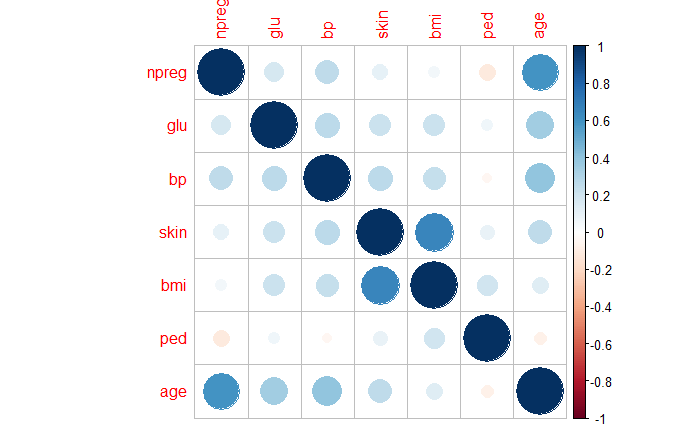

```r
library(corrplot)
corrplot(cor(x))
```

## How about pairwise relationships

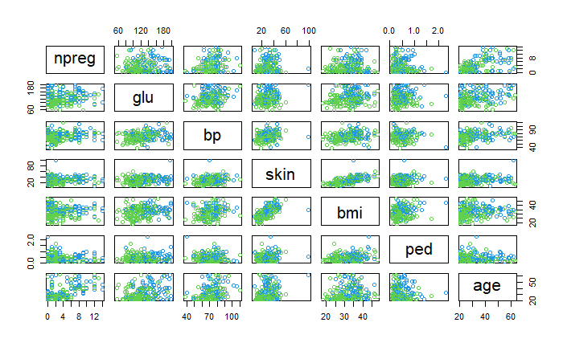

```r
plot(x, col=as.numeric(y)+2)
```

## How would each variable perform if left alone

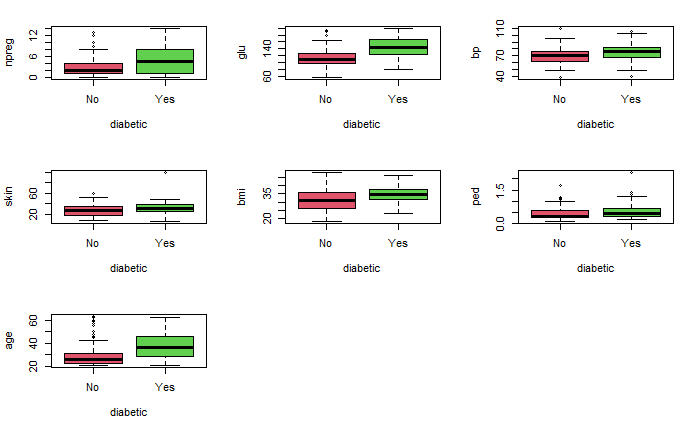

```r
 par(mfrow=c(3,3))
 for(j in 1:p)
 {
   boxplot(x[,j]~y, col=2:3, ylab=colnames(x)[j], xlab='diabetic')
 }
```

## What do the variables look like?

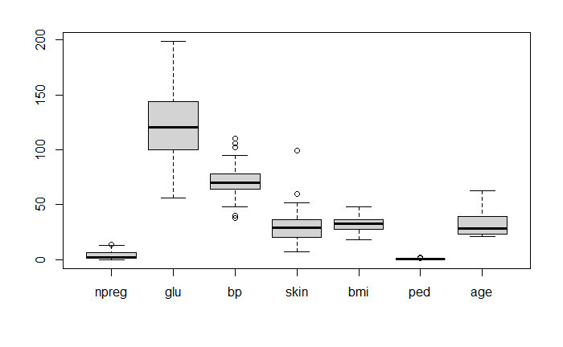

```r
  boxplot(x)
```

## What is the distribution of the response?

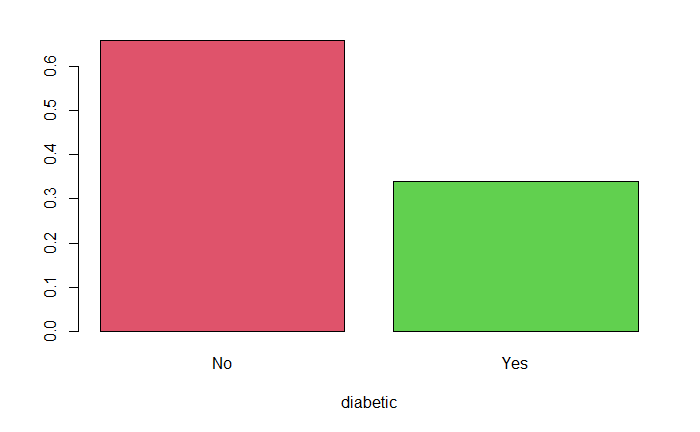

```r
  barplot(prop.table(table(y)), col=2:3, xlab='diabetic')
```

## Change labels for ROC later

```r
   xy[,pos] <- as.factor(ifelse(xy[,pos]==unique(xy[,pos])[1],1,0))
    y       <- as.factor(ifelse(y==unique(y)[1],1,0))
```

## Split of the data into training set and test set

```r
# Split the data

  set.seed (19671210)   # Set seed for random number generation to be reproducible

  epsilon <- 1/3               # Proportion of observations in the test set
  nte     <- round(n*epsilon)  # Number of observations in the test set
  ntr     <- n - nte

  id.tr   <- sample(sample(sample(n)))[1:ntr]   # For a sample of ntr indices from {1,2,..,n}
  #id .tr <- sample(1:n, ntr, replace=F)        # Another way to draw from {1,2,..n}
  id.te   <- setdiff(1:n, id.tr)
```

## Predictive performance of the 9-Nearest Neighbors Classifier

As you know by now, nearest neighbors learning machines are so-called lazy learners since there is no estimation per se in the traditional sense of storing a model. Instead, all the nearest neighbors machine does is perform predictions. If $\mathcal{Y}$ represents our output space and $\mathcal{X}$ represent our input space, and $\mathcal{V}_k(x)$ represents the set of the $k$ nearest neighbors of $x \in \mathcal{X}$ in the provided dataset $\mathcal{D}_n$, then the predicted class $\widehat{f}_{\tt kNN}(x)$ of $x \in \mathcal{X}$ is given by
$$\widehat{f}_{\tt kNN}(x) = \underset{c \in \mathcal{Y}}{{\tt argmax}}\Bigg\{\frac{1}{k}\sum_{i=1}^n{{\bf 1}(x_i \in \mathcal{V}_k(x)){\bf 1}(y_i=c)}\Bigg\}$$
Below, we start by considering the 9 nearest neighbors binary classifier on the test set, and the corresponding confusion matrix is generated

```r
  k        <- 9
  y.te     <- y[id.te]                                 # True responses in test set
  y.te.hat <- knn(x[id.tr,], x[id.te,], y[id.tr], k=k) # Predicted responses in test set

  conf.mat.te <- table(y.te, y.te.hat)
  conf.mat.te
```

```
    y.te.hat
y.te  0  1
   0 12 15
   1  5 35
```

We now consider a different and very special nearest neighbors learning machines, namely the 1 nearest neighbor or simply nearest neighbor learning machine. This time we first consider only the training set, and generate the corresponding confusion matrix

```r
  k        <- 1
  y.tr     <- y[id.tr]                                 # True responses in test set
  y.tr.hat <- knn(x[id.tr,], x[id.tr,], y[id.tr], k=k) # Predicted responses in test set

  conf.mat.tr <- table(y.tr, y.tr.hat)
  conf.mat.tr
```

```
    y.tr.hat
y.tr  0  1
   0 41  0
   1  0 92
```

We can see above something quite remarkable in the confusion matrix.

## Exercise

Explain why the off diagonal have the values observed Generate the 1NN test set confusion matrix

Below we set alternative ways of generating the very same quantities encountered earlier. This is provided here just for completeness and one can choose any of the ways to generate the predictive quantities of interest

```r
# Indicator of error in test

  ind.err.te <- ifelse(y.te!=y.te.hat,1,0)      # Random variable tracking error. Indicator
  ind.err.te
```

```
 [1] 0 0 1 0 1 0 1 0 0 0 0 0 1 0 0 0 0 0 0 0 0 0 0 1 1 0 0 1 0 1 0 0 0 0 1 1 0 0 1 0 0 0 0 0 1 0 0 0 1 0 0
[52] 0 0 1 0 0 0 1 1 1 1 1 0 0 1 0 0
```

```r
# Identification of misclassified cases

  id.err     <- which(y.te!=y.te.hat)           # Which obs are misclassified
  id.err
```

```
 [1]  3  5  7 13 24 25 28 30 35 36 39 45 49 54 58 59 60 61 62 65
```

```r
# Confusion matrix

  conf.mat.te <- table(y.te, y.te.hat)
  conf.mat.te
```

```
    y.te.hat
y.te  0  1
   0 12 15
   1  5 35
```

```r
# Percentage of correctly classified (accurary)

  pcc.te <- sum(diag(conf.mat.te))/nte
  # pcc.te <- 1-mean(ind.err.te)        # Another way from ind.err.te
  # pcc.te <- 1-length(id.err.te)/nte   # Yet another way fr
  pcc.te
```

```
[1] 0.7014925
```

```r
# Test Error

  err.te <- 1-pcc.te                    # Complement of accurary
  err.te
```

```
[1] 0.2985075
```

$$\widehat{R}^{(tr)}(\widehat{f})= \frac{1}{|\mathcal{D}_n^{(tr)}|}\sum_{i=1}^n{{\bf 1}(z_i \in \mathcal{D}_n^{(tr)}){\tt loss}(y_i, \widehat{f}(x_i))}$$
The corresponding test error is
$$\widehat{R}^{(te)}(\widehat{f})= \frac{1}{|\mathcal{D}_n^{(te)}|}\sum_{i=1}^n{{\bf 1}(z_i \in \mathcal{D}_n^{(te)}){\tt loss}(y_i, \widehat{f}(x_i))}$$
Where we also crucially have
$$\mathcal{D}_n^{(tr)} \cup \mathcal{D}_n^{(te)} = \mathcal{D}_n$$
So that
$$|\mathcal{D}_n^{(tr)}| + |\mathcal{D}_n^{(te)}| = |\mathcal{D}_n| = n.$$

The loss function used in the above errors is simply the famous zero-one loss, namely
$${\tt loss}(y, f(x)) = {\tt zeroone}(y, f(x)) = {\bf 1}(y\neq f(x))=
\left\{
\begin{array}{ll}
1 & \text{if}\,\, y \neq f(x) \\
0 & \text{if}\,\, y = f(x)
\end{array}\right.$$

## Receiver Operating Characteristics (ROC) Curves

We now turn to the creation of the very appealing graphic summary known as the ROC curve. This is arguably one of the best tools in binary classification as it allows the straightforward and very intuitive graphical way of assessing the predictive performance of a binary classifier. The ROC curve is built from two main ingredients, namely the True Positive Rate (TPR) and the False Positive Rate (FPR). For a given estimated learning machine $\widehat{f}$, we have

$${\tt TPR}(\widehat{f}) = \Pr(\widehat{f}(X)= +1 | Y = +1) = \frac{\Pr(\widehat{f}(X)=+1 \, \text{and} \, Y = +1) }{\Pr(Y = + 1)}$$
and

$${\tt FPR}(\widehat{f}) = \Pr(\widehat{f}(X)= +1 | Y = -1) = \frac{\Pr(\widehat{f}(X)=+1 \, \text{and} \, Y = -1) }{\Pr(Y = - 1)}$$
IN practice we neither have ${\tt FPR}(\widehat{f})$ nor ${\tt TPR}(\widehat{f})$, but instead their estimator $\widehat{{\tt FPR}(\widehat{f})}$ and $\widehat{{\tt TPR}(\widehat{f})}$ respectively.

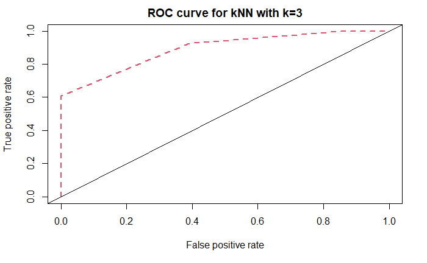

```r
#
#  ROC Curve: Plotting one single ROC Curve
#
  library(ROCR)

  y.roc <- y # as.factor(ifelse(y=='Yes',0,1))

  kNN.mod <- class::knn(x[id.tr,], x[id.tr,], y.roc[id.tr], k=3, prob=TRUE)
  prob    <- attr(kNN.mod, 'prob')
  prob    <- 2*ifelse(kNN.mod == "0", 1-prob, prob) - 1

  pred.knn <- prediction(prob, y.roc[id.tr])
  perf.knn <- performance(pred.knn, measure='tpr', x.measure='fpr')

  plot(perf.knn, col=2, lwd= 2, lty=2, main=paste('ROC curve for kNN with k=3'))
  abline(a=0,b=1)
```

We now consider the creation of the ROC curves of our binary classifiers, but this time based on the training set

```r
#
# Comparative ROC Curves on the training set
#
  library(ROCR)

  y.roc <- y #as.factor(ifelse(y=='Yes',0,1))

  kNN.mod <- class::knn(x[id.tr,], x[id.tr,], y.roc[id.tr], k=1, prob=TRUE)
  prob    <- attr(kNN.mod, 'prob')
  prob    <- 2*ifelse(kNN.mod == "0", 1-prob, prob) - 1

  pred.1NN <- prediction(prob, y.roc[id.tr])
  perf.1NN <- performance(pred.1NN, measure='tpr', x.measure='fpr')

  kNN.mod <- class::knn(x[id.tr,], x[id.tr,], y.roc[id.tr], k=13, prob=TRUE)
  prob    <- attr(kNN.mod, 'prob')
  prob    <- 2*ifelse(kNN.mod == "0", 1-prob, prob) - 1

  pred.13NN <- prediction(prob, y.roc[id.tr])
  perf.13NN <- performance(pred.13NN, measure='tpr', x.measure='fpr')

  kNN.mod <- class::knn(x[id.tr,], x[id.tr,], y.roc[id.tr], k=28, prob=TRUE)
  prob    <- attr(kNN.mod, 'prob')
  prob    <- 2*ifelse(kNN.mod == "0", 1-prob, prob) - 1

  pred.28NN <- prediction(prob, y.roc[id.tr])
  perf.28NN <- performance(pred.28NN, measure='tpr', x.measure='fpr')

  plot(perf.1NN, col=2, lwd= 2, lty=2, main=paste('Comparative ROC curves in Training'))
  plot(perf.13NN, col=3, lwd= 2, lty=3, add=TRUE)
```

```r
  plot(perf.28NN, col=4, lwd= 2, lty=4, add=TRUE)
  abline(a=0,b=1)
```

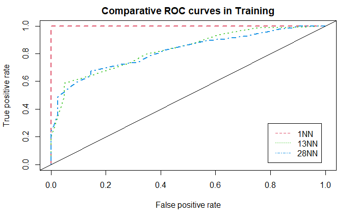

```r
  legend('bottomright', inset=0.05, c('1NN','13NN', '28NN'),  col=2:4, lty=2:4)
```

The comparatibve ROC curves based on the training set appear to declare the famous 1NN classifier the winner. However, this result is not valid, but the predictive comparisons are only truly meaningful if they are based on the test set.

```r
#
# Comparative ROC Curves on the test set
#
  library(ROCR)

  y.roc <- y #as.factor(ifelse(y=='Yes',0,1))

  kNN.mod <- class::knn(x[id.tr,], x[id.te,], y.roc[id.tr], k=1, prob=TRUE)
  prob    <- attr(kNN.mod, 'prob')
  prob    <- 2*ifelse(kNN.mod == "0", 1-prob, prob) - 1

  pred.1NN <- prediction(prob, y.roc[id.te])
  perf.1NN <- performance(pred.1NN, measure='tpr', x.measure='fpr')

  kNN.mod <- class::knn(x[id.tr,], x[id.te,], y.roc[id.tr], k=6, prob=TRUE)
  prob    <- attr(kNN.mod, 'prob')
  prob    <- 2*ifelse(kNN.mod == "0", 1-prob, prob) - 1

  pred.6NN <- prediction(prob, y.roc[id.te])
  perf.6NN <- performance(pred.6NN, measure='tpr', x.measure='fpr')

  kNN.mod <- class::knn(x[id.tr,], x[id.te,], y.roc[id.tr], k=13, prob=TRUE)
  prob    <- attr(kNN.mod, 'prob')
  prob    <- 2*ifelse(kNN.mod == "0", 1-prob, prob) - 1

  pred.13NN <- prediction(prob, y.roc[id.te])
  perf.13NN <- performance(pred.13NN, measure='tpr', x.measure='fpr')

  kNN.mod <- class::knn(x[id.tr,], x[id.te,], y.roc[id.tr], k=28, prob=TRUE)
  prob    <- attr(kNN.mod, 'prob')
  prob    <- 2*ifelse(kNN.mod == "0", 1-prob, prob) - 1

  pred.28NN <- prediction(prob, y.roc[id.te])
  perf.28NN <- performance(pred.28NN, measure='tpr', x.measure='fpr')

  plot(perf.1NN, col=2, lwd= 2, lty=2, main=paste('Comparison of Predictive ROC curves'))
  plot(perf.6NN, col=3, lwd= 2, lty=3, add=TRUE)
```

```r
  plot(perf.13NN, col=4, lwd= 2, lty=4, add=TRUE)
  plot(perf.28NN, col=5, lwd= 2, lty=5, add=TRUE)
```

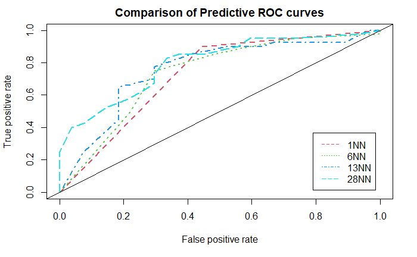

```r
  abline(a=0,b=1)
  legend('bottomright', inset=0.05, c('1NN','6NN','13NN', '28NN'),  col=2:5, lty=2:5)
```

We see now from the above comparative ROC curves, that 1NN is no longer the winner. It’s apparent superior performance on the training set was most likely due to overfitting. This is an important lesson to learn, namely that one must base predictive comparisons on generalization which is mimic by the test set

## Cross Validation for Selection Models within a Function Space

Within the implicit function space from which each of the k Nearest Neighbors machines are chosen, it is of great interest to find a strategy or a least a criterion for choosing a member of the space, in this case the size of the neighborhood $k$. It turns out that cross validation does allow us to determine the neighborhood size $k$.

$${\tt CV}(\widehat{f}) = \frac{1}{V}\sum_{v=1}^{V}{\widehat{e}_v(\widehat{f})}$$
where the $v^{th}$ cross validated error $\widehat{e}_v(\widehat{f})$, is the error made by $\widehat{f}$ on the $v^{th}$ chunk of the $\mathcal{D}_n$, with that left out chunk not having been used in the training of $\widehat{f}$, ie
$$\widehat{e}_v(\widehat{f}) = \frac{1}{|\mathcal{D}_n^{(v)}|}\sum_{i=1}^n{\mathbf{1}(z_i \in \mathcal{D}_n^{(v)}){\tt loss}(y_i,\widehat{f}^{(-v)}(x_i))}$$
where $z_i=(x_i, y_i)$ and $\widehat{f}^{(-v)}(\cdot)$ is estimator $\widehat{f}$ obtained on data without the $v^{th}$ chunk $\mathcal{D}_n^{(v)}$.

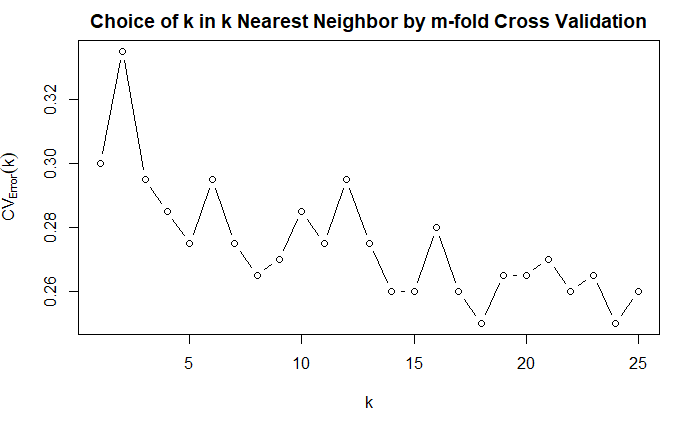

```r
  xtr <- x #x[id.tr,]          # Using the only the training for validation
  ytr <- y #y[id.tr]           # We could use the entire sample but that's greedy

  vK <- seq(1, 25, by=1)    # Grid of values of k
  nK <- length(vK)          # Number of values of k considered
  cv.error <-numeric(nK)    # Vector of cross validation errors for each k
  nc <- nrow(xtr)           # Number of observations used for cross validation
  c   <- 10                 # Number of folds. We are doing c-fold cross validation

  S   <- sample(sample(nc)) # We randomly shuffle the data before starting CV
  m   <- ceiling(nc/c)      # Maximum Number of observations in each fold

  held.out.set <- matrix(0, nrow=c, ncol=m) # Table used to track the evolution

  for(ic in 1:(c-1))
  {
    held.out.set[ic,] <- S[((ic-1)*m + 1):(ic*m)]
  }
  held.out.set[c, 1:(nc-(c-1)*m)] <- S[((c-1)*m + 1):nc]  # Handling last chunk just in case n!=mc

#
# Running the cross validation itself
#
  for(j in 1:nK)
  {
    for(i in 1:c)
    {
      out <-  held.out.set[i,]
      yhatc<- knn(xtr[-out,], xtr[out,],ytr[-out],  k=vK[j])
      cv.error[j]<-cv.error[j] + (length(out)-sum(diag(table(ytr[out],yhatc))))/length(out)
    }
    cv.error[j]<-cv.error[j]/c
  }

#
# Plot the cross validation curve
#
  plot(vK, cv.error, xlab='k', ylab=expression(CV[Error](k)),
      main='Choice of k in k Nearest Neighbor by m-fold Cross Validation')
  lines(vK, cv.error, type='c')
```

For a nicer looking plot, we resort to the famous ggplot

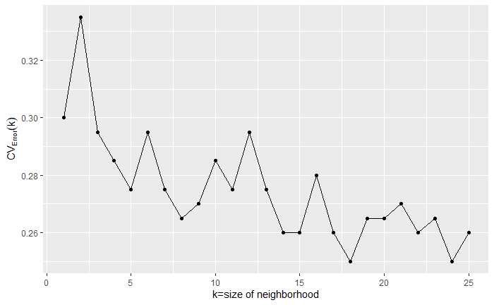

```r
#
#  Nicer plot with ggplot2
#

  cv <- data.frame(vK, cv.error)
  colnames(cv) <- c('k','error')

  ggplot(cv, aes(k,error))+geom_point()+geom_line()+
    labs(x='k=size of neighborhood', y=expression(CV[Error](k)))
```

## Predictive performance using stochastic hold out

Once members of various function spaces are chosen using perhaps cross validation as above, it becomes interesting to compare several methods via many copies of their test errors generated randomly via stochastic hold out. We first do it for a single learning machine and then we move on to several different learning machines

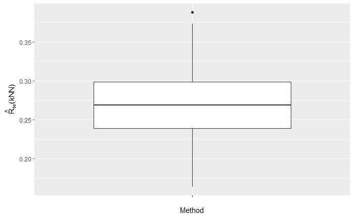

```r
#
# Extract the optimal k yielded by cross validation
#
  k.opt.cv <- max(which(cv.error==min(cv.error)))

##############################################################
# Using the optimally tuned k let's estimate the test error  #
##############################################################

  set.seed (19671210)          # Set seed for random number generation to be reproducible

  epsilon <- 1/3               # Proportion of observations in the test set
  nte     <- round(n*epsilon)  # Number of observations in the test set
  ntr     <- n - nte

  #k.opt.cv <- 28

  R <- 100   # Number of replications
  test.err <- numeric(R)

  for(r in 1:R)
  {
    # Split the data

    id.tr   <- sample(sample(sample(n)))[1:ntr]                   # For a sample of ntr indices from {1,2,..,n}
    id.te   <- setdiff(1:n, id.tr)

    y.te         <- y[id.te]                                        # True responses in test set
    y.te.hat     <- knn(x[id.tr,], x[id.te,], y[id.tr], k=k.opt.cv) # Predicted responses in test set
    ind.err.te   <- ifelse(y.te!=y.te.hat,1,0)                      # Random variable tracking error. Indicator
    test.err[r]  <- mean(ind.err.te)
  }

  test <- data.frame(test.err)
  colnames(test) <- c('error')

  ggplot(test, aes(x='', y=error))+geom_boxplot()+
  labs(x='Method', y=expression(hat(R)[te](kNN)))
```

```r
  ##############################################################
  #  Predictively compare different kNN  learning machines     #
  ##############################################################
```

We now consider the actually comparison of various different learning machines in terms of their predictive performances obtained via stochastic hold out. In this case, we are comparing different members of the nearest neighbors paradigm, but in reality, we can and will consider learning machines originating from drastically different paradigms

```r
  set.seed (19671210)          # Set seed for random number generation to be reproducible

  epsilon <- 1/3               # Proportion of observations in the test set
  nte     <- round(n*epsilon)  # Number of observations in the test set
  ntr     <- n - nte

  R <- 100   # Number of replications
  test.err <- matrix(0, nrow=R, ncol=5)

  for(r in 1:R)
  {
    # Split the data

    id.tr   <- sample(sample(sample(n)))[1:ntr]                   # For a sample of ntr indices from {1,2,..,n}
    id.te   <- setdiff(1:n, id.tr)

    y.te         <- y[id.te]                                        # True responses in test set

    # First machine: 1NN

    y.te.hat     <- knn(x[id.tr,], x[id.te,], y[id.tr], k=1)        # Predicted responses in test set
    ind.err.te   <- ifelse(y.te!=y.te.hat,1,0)                      # Random variable tracking error. Indicator
    test.err[r,1]  <- mean(ind.err.te)

    # Second machine: Our optimal NN found earlier with k=k.opt.cv
    y.te.hat     <- knn(x[id.tr,], x[id.te,], y[id.tr], k=k.opt.cv) # Predicted responses in test set
    ind.err.te   <- ifelse(y.te!=y.te.hat,1,0)                      # Random variable tracking error. Indicator
    test.err[r,2]  <- mean(ind.err.te)

    # Third machine: k=round(sqrt(n))
    y.te.hat     <- knn(x[id.tr,], x[id.te,], y[id.tr], k=round(sqrt(n)))       # Predicted responses in test set
    ind.err.te   <- ifelse(y.te!=y.te.hat,1,0)                      # Random variable tracking error. Indicator
    test.err[r,3]  <- mean(ind.err.te)


  # Fourth machine: k=round(log(n))
    y.te.hat     <- knn(x[id.tr,], x[id.te,], y[id.tr], k=round(log(n)))       # Predicted responses in test set
    ind.err.te   <- ifelse(y.te!=y.te.hat,1,0)                      # Random variable tracking error. Indicator
    test.err[r,4]  <- mean(ind.err.te)


  # Fourth machine: k=log(n)
    y.te.hat     <- knn(x[id.tr,], x[id.te,], y[id.tr], k=n)       # Predicted responses in test set
    ind.err.te   <- ifelse(y.te!=y.te.hat,1,0)                      # Random variable tracking error. Indicator
    test.err[r,5]  <- mean(ind.err.te)
  }
```

[output not shown]

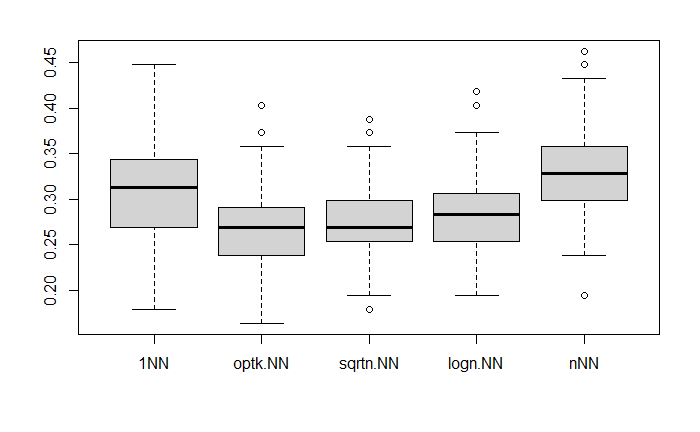

```r
  test <- data.frame(test.err)
  Method<-c('1NN', 'optk.NN', 'sqrtn.NN', 'logn.NN', 'nNN')
  colnames(test) <- Method
  boxplot(test)
```

Once again, we also produce a nicer looking version of the same plot using the famous ggplot

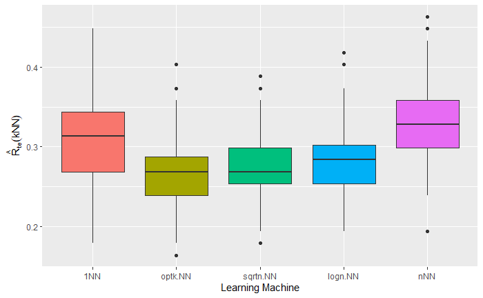

```r
  require(reshape2)
  ggplot(data = melt(test), aes(x=variable, y=value)) + geom_boxplot(aes(fill=variable))+
    labs(x='Learning Machine', y=expression(hat(R)[te](kNN)))+
    theme(legend.position="none")
```

## Analysis of Variance

From a purely statistical perspective, it often becomes important to perform the inferential method of analysis of variance to more rigorously and more formally compare the learning machines under consideration

```r
#
# Is the difference between the methods significant
#
  aov.method <- aov(value~variable, data=melt(test))
  anova(aov.method)
```

```
Analysis of Variance Table

Response: value
           Df  Sum Sq  Mean Sq F value    Pr(>F)
variable    4 0.28429 0.071073  32.281 < 2.2e-16 ***
Residuals 495 1.08984 0.002202
---
Signif. codes:  0 ‘***’ 0.001 ‘**’ 0.01 ‘*’ 0.05 ‘.’ 0.1 ‘ ’ 1
```

```r
  #summary(aov.method)

  TukeyHSD(aov.method, ordered = TRUE)
```

```
  Tukey multiple comparisons of means
    95% family-wise confidence level
    factor levels have been ordered

Fit: aov(formula = value ~ variable, data = melt(test))

$variable
                        diff          lwr        upr     p adj
sqrtn.NN-optk.NN 0.010597015 -0.007570928 0.02876496 0.5000305
logn.NN-optk.NN  0.016567164 -0.001600779 0.03473511 0.0930089
1NN-optk.NN      0.041343284  0.023175340 0.05951123 0.0000000
nNN-optk.NN      0.066119403  0.047951460 0.08428735 0.0000000
logn.NN-sqrtn.NN 0.005970149 -0.012197794 0.02413809 0.8969605
1NN-sqrtn.NN     0.030746269  0.012578325 0.04891421 0.0000452
nNN-sqrtn.NN     0.055522388  0.037354445 0.07369033 0.0000000
1NN-logn.NN      0.024776119  0.006608176 0.04294406 0.0019594
nNN-logn.NN      0.049552239  0.031384296 0.06772018 0.0000000
nNN-1NN          0.024776119  0.006608176 0.04294406 0.0019594
```

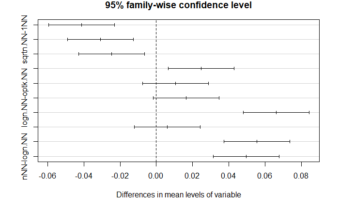

```r
  plot(TukeyHSD(aov.method))
```

The comparison in this case is trivial.